# Driver detection with dndscv

Federico Abascal

14/09/2022

## Detecting drivers in bladder carcinoma

We will be detecting drivers in the TCGA consortium bladder carcinoma dataset. These data are exomes from 370 donors with bladder cancer.

### Data loading and exploration

First, we load the data:

`muts = read.table("/home/manager/data/Driver_detection_20220823T163817Z- 001/Driver_detection/TCGA-BLCA.5col",header=T,sep="\t",stringsAsFactors=F)`

It is always a good idea to explore the data first.

```r
head(muts)
```

```
##       sampleID chr       pos ref mut
## 1 TCGA-2F-A9KO  10 101715548   C   T
## 2 TCGA-2F-A9KO  10 102822569   G   A
## 3 TCGA-2F-A9KO  10 103826020   C   T
## 4 TCGA-2F-A9KO  10 104160055   G   C
## 5 TCGA-2F-A9KO  10 118666167   C   T
## 6 TCGA-2F-A9KO  10  12043694   C   G
```

To count the number of samples and mutations we can do the following:

```r
length(unique(muts$sampleID))
```

```
## [1] 370
```

```r
nrow(muts)
```

```
## [1] 53518
```

There are 370 donors and a total of 53518 mutations. We can also have a look at the mutation burden across the 370 donors:

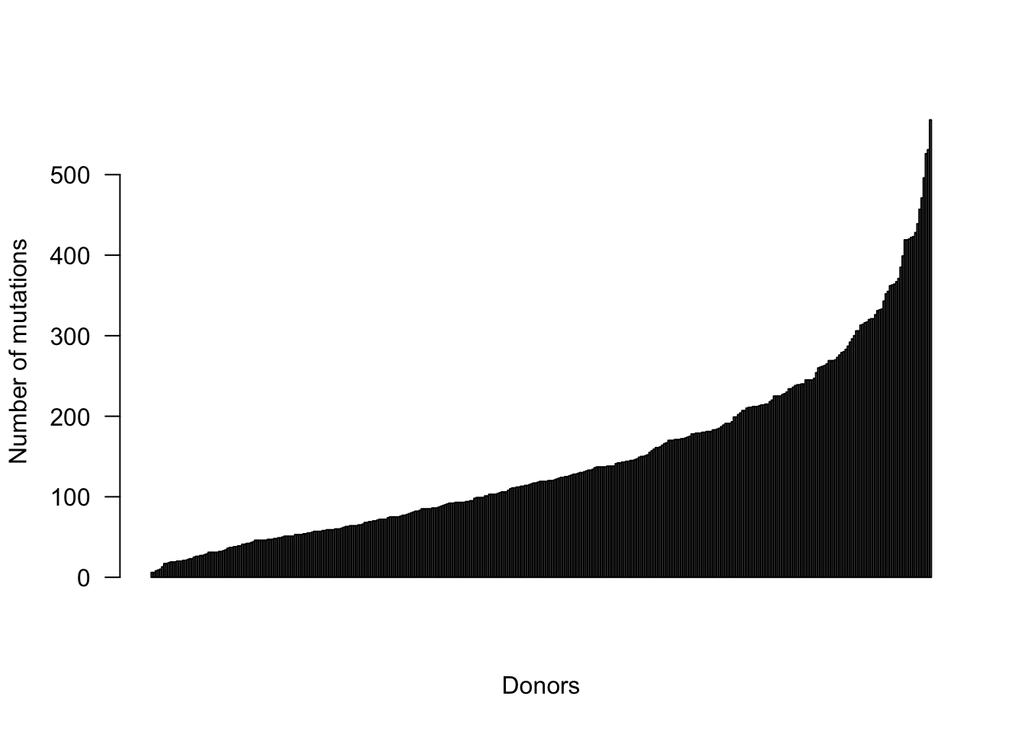

```r
barplot(sort(table(muts$sampleID)),ylab="Number of mutations",xlab="Donors",las=2,names.arg="")
```

**Are there any hypermutators in the cohort?** This is a relevant question because hypermutators can have a negative impact on the statistical power to detect drivers, and also because some hypermutators (e.g. POLE) are under mutational processes which are not properly modeled by a trinucleotide-substitution model.

### dndscv analysis

Now we will proceed to detect drivers in bladder cancer, searching for genes with evidence of positive selection with `dndscv`.

```r
library(dndscv)
```

#### Gene level signals of selection

We will run `dndscv` removing hypermutators (n>500) and when a given sample has more than 3 mutations in a given gene, `dndscv` will choose three randomly. This is to "protect against loss of sensitivity from ultra-hypermutators and from clustered artefacts in the input mutation table, but there are occasions when the user will prefer to relax these".

```r
dout = dndscv(muts,max_muts_per_gene_per_sample=3,max_coding_muts_per_sample=500,outmats=T)
```

```
## [1] Loading the environment...
```

```
## [2] Annotating the mutations...
```

```
##     Note: 1 samples excluded for exceeding the limit of mutations per sample (see the max_coding_muts_per_sample argument in dndscv). 369 samples left after filtering.
```

```
##     Note: 229 mutations removed for exceeding the limit of mutations per gene per sample (see the max_muts_per_gene_per_sample argument in dndscv)
```

```
##     22% ...
```

```
##     43% ...
```

```
##     65% ...
```

```
##     86% ...
```

```
## [3] Estimating global rates...
```

```
## [4] Running dNdSloc...
```

```
## [5] Running dNdScv...
```

```
##     Regression model for substitutions (theta = 6.65).
```

```
##     Regression model for indels (theta = 0.422)
```

These are the outputs within the `dout` list:

```r
names(dout)
```

```
##  [1] "globaldnds"   "sel_cv"       "sel_loc"      "annotmuts"    "genemuts"
##  [6] "geneindels"   "mle_submodel" "exclsamples"  "exclmuts"     "nbreg"
## [11] "nbregind"     "poissmodel"   "wrongmuts"    "N"            "L"
```

##### Table of signficant genes

`dout$sel_cv` contains the results for all the analysed genes.

We will have a look at those with `qglobal_cv < 0.1`. This is the multiple hypotheses correction q-value for `pglobal_cv`. And `pglobal_cv` is the combined p-value for the different p-values calculated.

```r
dout$sel_cv[which(dout$sel_cv$qglobal_cv<0.1),]
```

```
##             gene_name n_syn n_mis n_non n_spl n_ind   wmis_cv    wnon_cv
## 18057            TP53     3    82    14     1    12 53.092352  85.566153
## 12977          PIK3CA     1    44     0     0     0 18.717174   0.000000
## 1465           ARID1A     2    21    29     2    16  4.482524  62.492704
## 9207            KMT2D     6    19    24     5    16  1.465238  20.858366
## 14249             RB1     0     3    21     9    11  1.635651 110.255813
## 8939            KDM6A     3    12    13     5    12  3.368083  34.351581
## 16808           STAG2     1     8    11     2     8  3.286180  41.225276
## 5641             ELF3     0    18     1     0    12 18.535061   8.812791
## 3519           CDKN1A     1     3     3     0    13  6.602851  51.166925
## 6523            FGFR3     3    26     1     0     0 13.997261   5.943960
## 3523  CDKN2A.p16INK4a     0     6     1     1     3 16.344982  84.538504
## 3522    CDKN2A.p14arf     0     6     0     1     3 18.718600  63.957183
## 14506            RHOB     0    14     0     0     0 26.026691   0.000000
## 14505            RHOA     1    12     0     0     0 26.045683   0.000000
```

[output cut: 87 more lines]

The table contains 3 types of columns: the data (number of mutations of different types), the coefficients of selection (w), and the associated statistical significance (p and q-values).

In total there are 33 signficant genes.

**Is there any gene under negative selection?**

**Which ones do you think are oncogenes (gain of function) and which tumour suppressors?** Tip: to answer this question you can look at the number of different types of mutations in these genes (`n_syn`, `n_mis`, `n_non`, `n_spl`, `n_ind`)

Considering the coefficient of selection for missense mutations in *ARID1A*, **how many missense mutations had been selected for in this cohort?** Tip: the coefficient `wmis_cv`is 4.4825244 and there are 21 missense mutations in ARID1A. Tip 2: `(w-1)/w` gives the proportion under positive selection. Tip 3: 95% confindence intervals for the selection coefficients can be obtained with `geneci(dout,gene_list="ARID1A")`. Tip 4: Have a look at `genemuts` to see how many mutations were expected

```r
dout$genemuts[which(dout$genemuts$gene_name=="ARID1A"),]
```

```
##      gene_name n_syn n_mis n_non n_spl  exp_syn  exp_mis   exp_non  exp_spl
## 1465    ARID1A     2    21    29     2 2.100349 5.592629 0.5095613 0.082616
##      exp_syn_cv
## 1465   1.986097
```

**Are all those missense mutations under selection?** **Why could this be importance when looking at the mutations in a given tumour?**

Look at the mutations in *PIK3CA*:

```
##           sampleID chr       pos ref mut   gene strand ref_cod mut_cod ref3_cod
## 255   TCGA-2F-A9KO   3 178938934   G   A PIK3CA      1       G       A      TGA
## 1028  TCGA-2F-A9KW   3 178936091   G   A PIK3CA      1       G       A      TGA
## 3289  TCGA-4Z-AA84   3 178941935   C   G PIK3CA      1       C       G      TCT
## 3618  TCGA-4Z-AA87   3 178937518   G   C PIK3CA      1       G       C      AGT
## 3717  TCGA-4Z-AA89   3 178916891   G   A PIK3CA      1       G       A      CGG
## 3718  TCGA-4Z-AA89   3 178921553   T   A PIK3CA      1       T       A      ATG
## 3864  TCGA-5N-A9KI   3 178921339   G   A PIK3CA      1       G       A      AGA
## 3865  TCGA-5N-A9KI   3 178936091   G   A PIK3CA      1       G       A      TGA
## 5451  TCGA-BT-A20O   3 178936082   G   A PIK3CA      1       G       A      TGA
## 5759  TCGA-BT-A20R   3 178936091   G   A PIK3CA      1       G       A      TGA
## 9814  TCGA-CF-A5UA   3 178916836   C   G PIK3CA      1       C       G      TCA
## 10685 TCGA-CU-A5W6   3 178936094   C   A PIK3CA      1       C       A      GCA
## 11346 TCGA-DK-A1A5   3 178942564   G   C PIK3CA      1       G       C      AGA
## 11884 TCGA-DK-A1AB   3 178952074   G   T PIK3CA      1       G       T      TGA
```

[output cut: 77 more lines]

```
##
##  E365K  E417K  E726K  E791Q G1049R  G451V  L671L  L752V  L956F M1004V M1043I
##      1      1      1      1      1      1      1      1      1      1      1
##  N345K  P471A  Q546K  Q546R   Q75E  R274K   R88Q   R93Q   S66C  V636L  E453K
##      1      1      1      1      1      1      1      1      1      1      2
##  E545Q H1047R  E542K  E545K
##      2      2      8     10
```

*We will later see how to use the `dndscv` package for hotspot analyses*

#### Global signals of selection

`dndscv` estimates also global dN/dS ratios in the aggregate of all genes. This result is also part of the main `dndscv` output:

```
##      name       mle     cilow    cihigh
## wmis wmis 1.0524348 1.0290546 1.0763461
## wnon wnon 1.2269231 1.1735965 1.2826728
## wspl wspl 0.7915522 0.7297038 0.8586429
## wtru wtru 1.1045772 1.0612096 1.1497171
## wall wall 1.0629959 1.0398517 1.0866553
```

**Is there evidence of positive selection?**

We can use the `globaldnds` information to estimate the number of missense driver mutations per sample.

There are 30610 missense mutations in the cohort, and the coefficient of selection `wmis` is 1.0524348.

Calculate the proportion of missense mutations under positive selection using the formula `(w-1)/w`

Find out the actual number of missense mutations under positive selection: `n_mis * (w-1)/w`

Calculate the average per sample: `( n_mis * (w-1)/w ) / num_samples`

You can obtain all the info with:

`w = dout$globaldnds[1,2]`

`n_mis = length(which(dout$annotmuts$impact=="Missense"))`

`num_samples = table(unique(muts$sampleID))`

### Analysis of hotspots

We will now look for signals of positive selection at specific DNA or protein sites.

Firstly, have a look at the `annotmuts` output and try to determine by eye if there are hotspots. A couple lines of code which may help with the task:

```r
dout$annotmuts$gene_and_aachange = paste(dout$annotmuts$gene,dout$annotmuts$aachange,dout$annotmuts$ntchange,dout$annotmuts$pos,dout$annotmuts$impact,sep=":")
sort(table(dout$annotmuts$gene_and_aachange),decreasing=T)[1:10]
```

```
##
##     FGFR3:S249C:C746G:1803568:Missense      TP53:R248Q:G743A:7577538:Missense
##                                     13                                     11
## PIK3CA:E545K:G1633A:178936091:Missense PIK3CA:E542K:G1624A:178936082:Missense
##                                     10                                      8
##   RXRA:S427F:C1280T:137328351:Missense      TP53:E285K:G853A:7577085:Missense
##                                      7                                      6
##    ERBB2:S310F:C929T:37868208:Missense    FGFR3:Y375C:A1124G:1806099:Missense
##                                      5                                      5
##      TP53:R280T:G839C:7577099:Missense    C3orf70:S6L:C17T:184870595:Missense
##                                      5                                      4
```

Go to the COSMIC database to gather further information about these hotspots. For example:

*FGFR3* https://cancer.sanger.ac.uk/cosmic/gene/analysis?ln=FGFR3

Look at other hotspots, the domain structure, the 3D structure

The Hallmarks of Cancer has also valuable information on drivers: https://cancer.sanger.ac.uk/cosmic/census-page/FGFR3

**Do you think hotspots are more frequent in oncogenes or in tumour suppressors?**

#### Using sitednds and codondnds

`sitednds` looks for selection (mutation recurrence over random expectations) at specific DNA positions, while `codondnds` looks for selection at codons. Each method may be more sensitive for different kinds of hotspots, hence we recommend trying both.

##### Running sitednds

To reduce the risk of false positives and increase the signal to noise ratio, we will only consider mutations in Cancer Gene Census genes (v81).

```r
library("dndscv")
data("cancergenes_cgc81", package="dndscv") # Loading the genes in the Cancer Gene Census (v81)
dout_cancergenes = dndscv(muts, outmats=T, gene_list=known_cancergenes)
```

The *sitednds* function takes the output of *dndscv* as input. In order for the dndsout object to be compatible with *sitednds*, users must use the "outmats=T" argument in *dndscv*.

```r
sout = sitednds(dout_cancergenes)
```

```
## [1] Site-wise overdispersed model accounting for trinucleotides and relative gene mutability...
```

```
## [2] Calculating site-wise dN/dS ratios and p-values...
```

```
##     Using the conservative bound of the confidence interval of the overdispersion parameter.
```

```
##     Modelling substitution rates using a Negative Binomial: theta = 0.213 (CI95:0.0805,1.32)
```

The output list contains the following objects:

```r
names(sout)
```

```
## [1] "recursites"     "overdisp"       "fpr_nonsyn_q05" "LL"
```

We are mainly interested in `recursites`.

These are the significant sites:

```r
sout$recursites[which(sout$recursites$qval<0.1),]
```

```
##    chr       pos ref mut   gene aachange   impact ref3_cod mut3_cod freq
## 1    4   1803568   C   G  FGFR3    S249C Missense      TCC      TGC   13
## 2   17   7577538   C   T   TP53    R248Q Missense      CGG      CAG   11
## 3    3 178936091   G   A PIK3CA    E545K Missense      TGA      TAA   10
## 4    3 178936082   G   A PIK3CA    E542K Missense      TGA      TAA    8
## 5    4   1806099   A   G  FGFR3    Y375C Missense      TAT      TGT    5
## 6   19  45867687   T   C  ERCC2    N238S Missense      AAC      AGC    4
## 7    4 153247289   G   C  FBXW7    R505G Missense      CCG      CGG    4
## 8   17  37868208   C   T  ERBB2    S310F Missense      TCC      TTC    5
## 9   17   7577085   C   T   TP53    E285K Missense      AGA      AAA    6
## 10  17   7578454   G   A   TP53    A159V Missense      GCC      GTC    3
## 11  17   7577099   C   G   TP53    R280T Missense      AGA      ACA    5
## 12  17   7577539   G   A   TP53    R248W Missense      CCG      CTG    4
## 13  12  56478854   G   T  ERBB3    V104L Missense      CGT      CTT    3
##              mu       dnds         pval         qval
## 1  0.0008079132 16090.8379 7.376318e-29 3.573132e-22
## 2  0.0038932950  2825.3703 1.939040e-17 4.696412e-11
## 3  0.0046875620  2133.3051 2.692634e-15 4.347760e-09
## 4  0.0046875620  1706.6441 1.088835e-12 1.318595e-06
## 5  0.0007836589  6380.3270 1.592950e-12 1.543269e-06
## 6  0.0003810892 10496.2291 1.149977e-11 9.284260e-06
## 7  0.0005224576  7656.1236 4.039331e-11 2.795251e-05
## 8  0.0016794405  2977.1820 6.874221e-11 4.162392e-05
## 9  0.0051158831  1172.8181 7.681553e-10 4.134433e-04
## 10 0.0007043649  4259.1560 1.981545e-08 9.598719e-03
## 11 0.0056141654   890.6043 2.353526e-08 1.036420e-02
## 12 0.0033636803  1189.1736 6.200800e-08 2.503087e-02
## 13 0.0011948375  2510.8016 9.538711e-08 3.554314e-02
```

##### Running codondnds

We will not run it because it requires creating a new database, which can take about 20', but this is how you can do it.

```
data("refcds_hg19", package = "dndscv")
RefCDS_codon = buildcodon(RefCDS)
codon_dnds = codondnds(dout_cancergenes, RefCDS_codon, theta_option="conservative", min_recurr=2)
codon_dnds$recurcodons[which(codon_dnds$recurcodons$qval<0.1),]
```

The output should look something like this:

`codon_dnds$recurcodons[which(codon_dnds$recurcodons$qval<0.1),]`

```
   chr          gene codon freq           mu      dnds         pval         qval
1    4         FGFR3  S249   13 0.0026714453 4866.2797 2.621846e-25 1.376535e-19
2   17          TP53  R248   16 0.0099400778 1609.6453 7.833417e-22 2.056370e-16
3    3        PIK3CA  E545   12 0.0081868351 1465.7679 7.394593e-18 1.294115e-12
4   12          KRAS   G12    6 0.0014473316 4145.5601 2.651640e-14 3.480443e-09
5   17         ERBB2  S310    7 0.0032911176 2126.9371 6.485301e-14 6.809891e-09
6    3        PIK3CA  E542    8 0.0081206853  985.1385 1.365277e-12 1.194674e-07
7    4         FGFR3  Y375    5 0.0013764724 3632.4740 2.521340e-12 1.891095e-07
8   17          TP53  R280    8 0.0118571608  674.6978 2.381470e-11 1.562914e-06
9   19         ERCC2  N238    4 0.0011025375 3627.9944 1.384008e-10 8.073762e-06
10  17          TP53  E285    7 0.0124847138  560.6857 5.092478e-10 2.673678e-05
11   4         FBXW7  R505    4 0.0042853070  933.4220 2.947422e-08 1.406791e-03
12   2         SF3B1  E902    4 0.0050917631  785.5825 5.773892e-08 2.526198e-03
13  17          TP53  A159    4 0.0054963967  727.7495 7.772309e-08 3.138967e-03
14  12         ERBB3  V104    3 0.0042258838  709.9107 1.292705e-06 4.847876e-02
15   9 CDKN2A.p14arf   A97    2 0.0008437944 2370.2457 2.705783e-06 9.470692e-02
```

## Predicting drivers in a given donor using the Cancer Genome Interpreter

We will use the Cancer Genome Interpreter to predict drivers in one of our donors.

To make it more interesting, each one can select one donor randomly:

```r
random_donor = sample(unique(muts$sampleID),1)
muts_in_random_donor = muts[which(muts$sampleID == random_donor),c("chr","pos","ref","mut")]
cat(random_donor, " donor has ",nrow(muts_in_random_donor), " mutations\n",sep="")
```

```
## TCGA-FJ-A3Z9 donor has 46 mutations
```

```r
write.table(muts_in_random_donor, file=paste(random_donor,".tsv",sep=""),col.names=F,row.names=F,quote=F)
```

Copy those mutations and paste them here: https://www.cancergenomeinterpreter.org/analysis

Select hg19 as "Reference genome" and click "Run". The analysis will take a few minutes.

You can also explore bladder cancer at **Intogen**: https://www.intogen.org/search There you would find 78 drivers defined for bladder cancer

### Further tutorials and exercises

If you have finished or want to explore more on using dndscv, take a look at these tutorials. They are available at https://github.com/WCSCourses/cancer_genome_analysis_africa/tree/main/modules/Driver%20gene%20and%20oncoplots

- Drivers in healthy bladder (Lawson et al, *Science* 2020; PMID: 33004514). Interesting to compare the driver landscape in cancer and healthy tissues and to explore the heterogeneity across different donors. The code includes plotting functions.
- 2020, Romania course: Selection in oesophageal cancer, selection in de novo mutations, selection in germline variation.

Questions are welcome (fa8@sanger.ac.uk).